# Анализ аэропортов разных стран - Николай Смитиенко

## Резюме

С помощью beautiful soap я запарсил данные об аэропортаз в разных странах, с помощью регулярных выражений привел эти данные к удобному для работы виду, с помощью numpy посчитал расстояние между ними, с помощью networkx отразил крупнейшие цепочки аэропортов, расстояние между которыми не превышает определенного числа, с помощью geopandas отобразил аэропорты на карте определенной страны, c помощью дополнительной библиотеки pandasql отбирал данные(используя при этом sql), а также использовал matplotlib для построения круговой диаграммы, обозначающей доли аэропортов разного вида.

## Предыстория

Когда я был маленьким, я очень сильно мечтал научится летать. Мне это часто снилось, рисунки в детском садике были завязаны на самолетах и вертолетах, а сколько бумаги я испортил, делая бумажные летательные аппараты не сосчитать. Поэтому в этом проекте я решил закрыть небольшой детский гештальд и представить, что я путешевствую на самолете по какой-то конкретной стране, плавая в облаках. И, безусловно, для этого полета нужно знать, где мы можем остановиться и сколько аэропортов мы вообще можем пролететь, следовательно, необходимо проанализировать, как обстоят дела с аэропортами в той стране, где я собираюсь летать, в чем и состоит суть моего проекта

# Документация: функции и данные, которые будут использованы при анализе

## Парсинг

В процессе выполнения задачи я столкнулся с тем, что достаточно трудно найти данные об аэропортах, причем об аэропортах большей части стран крайне проблематично. К счастью, я нашел заслуживающий доверия ресурс, на котором были изображены таблицы с аэропортами разных стран.

### Парсинг названий стран

Чтобы попасть на страничку с табличкой с аэропортами той страны, которая нам интересна, необходимо было понять, как сайт обохначает разные страны в своем url. К счастью, это было нетрудно обнаружить на чуть ли не начальной странице http://www.fallingrain.com/world/

Далее привожу код, с помощью которого эти данные были собраны в словарь, с помощью которого можно было переводить название страны в обозначение

```python
import requests # импортируем необходимые библиотеки
from bs4 import BeautifulSoup

url_countries = 'http://www.fallingrain.com/world/index.html'
response = requests.get(url_countries)
countries_page = BeautifulSoup(response.text, 'lxml') # beautiful soap для парсинга

table_countries = countries_page.find_all('table')[1]

countries_data = table_countries.find_all('td')
countries = [i.text for i in countries_data]

countries = [countries[i].split(" ", 1) for i in range(len(countries))]
countries0 = []
countries1 = []
for i in range(len(countries)):
    countries0.append(countries[i][0])
    countries1.append(countries[i][1])
countries_dict = dict(zip(countries1, countries0))

del countries_dict['United States'] # делаем это поскольку страница США устроена иначе чем остальные
```

### Парсинг аэропортов конкретной страны и приведение данных в норму

Далее мы уже обладая "секретным" знанием того, как сайт создает url таблички, делаем функцию, которая будет парсить и возвращать нам датафрейм той, таблички, которая представлена нам на сайте

Функция принимает на вход строку, в которой написано название страны, возвращает датафрейм всех аэропортов страны

```python
import pandas as pd

def parse_airports(country):
    url_country = f'http://www.fallingrain.com/world/{countries_dict[country]}/airports.html'
    response = requests.get(url_country)
    page = BeautifulSoup(response.text, 'lxml')
    table1 = page.find('table')
    headers = []
    for i in table1.find_all('th'):
        title = i.text
        headers.append(title)
    country_data = pd.DataFrame(columns = headers)
    for j in table1.find_all('tr')[1:]:
        row_data = j.find_all('td')
        row = [i.text for i in row_data]
        length = len(country_data)
        country_data.loc[length] = row
    return country_data
```

Далее сделаем функцию, которая будет принимать на вход датафрейм и будет выводить его же, однако более удобного для работы и анализа

```python
import re

def airports_of_the_country(df):
    df = df.replace('', pd.NA)
    for i in range(len(df['Latitude'])):
        df.loc[i, 'Latitude'] = float(re.sub(r"...$", "", df.loc[i, 'Latitude'])) # используем регулярные выражения, иначе было бы слишком сложно
        df.loc[i, 'Longitude'] = float(re.sub(r"...$", "", df.loc[i, 'Longitude']))
    return df
```

На этом можно считать данные полученными и запарсенными

## Функция для графа аэропортов на определенном растоянии друг от друга

### Функция расстояния между двумя точками на земном шаре

Чтобы нарисовать граф с помощью библиотеки networkx нам сначала нужно понять, какое расстояние между аэропортами, которые мы рассматриваем

Для подсчетов воспользуемся формулой гарверсинусов

Функция принимает на вход координаты x1, y1 первого объекта и координаты x2, y2 второго, возвращает расстояние в километрах между объектами

```python
import numpy as np

def distance(x1, y1, x2, y2):
    x1 = np.radians(x1)
    x2 = np.radians(x2)
    y1 = np.radians(y1)
    y2 = np.radians(y2)
    r = 6372.7
    delta_y = y2 - y1
    delta_x = x2 - x1
    a = ( np.sin(delta_x/2) )**2 + np.cos(x1)*np.cos(x2)*(np.sin(delta_y/2))**2
    dist = 2*r*np.arcsin(np.sqrt(a))
    return dist
```

### Отображение графа аэропортов, между которыми расстояние меньше определенного

Теперь напишим функцию, которая будет принимать на вход датафрейм и максимальное расстояние между аэропортами, и будет рисовать граф, тех аэропортов, до которых можно будет долететь с не более чем max_dist растоянием от другого аэропорта

```python
import matplotlib.pyplot as plt
import networkx as nx
import pandasql as ps # дополнительная технология, не изучавшаяся во время курса

def possible_to_fly_graph(country, max_dist):
    df = airports_of_the_country(country)
    p = nx.Graph()
    for i in range(len(df)):
        for j in range(len(df)):
            dist = distance(df.loc[i, 'Longitude'], df.loc[i, 'Latitude'], df.loc[j, 'Longitude'], df.loc[j, 'Latitude'])
            if i != j and dist < max_dist:
                p.add_edge(df.loc[i, 'Name'], df.loc[j, 'Name'])
    nx.draw(p, with_labels = False, node_size = 10, pos=nx.circular_layout(p))  # рисуем граф
    plt.show
```

Сделаем такую же функцию, но только для средних и крупных аэропортов

```python
def possible_to_fly_medium_large_graph(country, max_dist):
    df = airports_of_the_country(country)
    select_df =  """SELECT Name, Latitude, Longitude
                    FROM df
                    WHERE (Kind = 'Medium' or Kind = 'Large')"""
    df = ps.sqldf(select_df, locals()) # использование sql

    p = nx.Graph()
    for i in range(len(df)):
        for j in range(len(df)):
            dist = distance(df.loc[i, 'Longitude'], df.loc[i, 'Latitude'], df.loc[j, 'Longitude'], df.loc[j, 'Latitude'])
            if i != j and dist < max_dist:
                p.add_edge(df.loc[i, 'Name'], df.loc[j, 'Name'])
    nx.draw(p, with_labels = False, node_size = 10, pos=nx.circular_layout(p))  # рисуем граф
    plt.show
```

## Функция отображения аэропортов на карте

Для начала импортируем необходимые библиотеки и скачаем карту мира

```python
import geopandas as gpd
from shapely.geometry import Point
```

```python
world_map = gpd.read_file("https://datahub.io/core/geo-countries/r/countries.geojson")
```

Теперь напишем функцию, которая будет принимать датафрейм и выводить карту страны с отмеченными на ней аэропортами(всеми в т.ч. закрытыми)

```python
def airports_on_the_map(country):
    df = airports_of_the_country(parse_airports(country))
    gdf = gpd.GeoDataFrame(df, geometry=gpd.points_from_xy(df.Longitude, df.Latitude), crs="EPSG:4326")
    cnry_map = world_map.loc[world_map['ADMIN'] == country]
    ax = cnry_map.plot(color="white", edgecolor="black")

    gdf.plot(ax=ax, color="red",  markersize=1)

    plt.show()
```

Теперь сделаем такую же функцию, но для средних и крупных аэропортов

```python
def airports_on_the_map_medium_large(country):
    df = airports_of_the_country(parse_airports(country))
    select_df =  """SELECT Name, Latitude, Longitude
                    FROM df
                    WHERE (Kind = 'Medium' or Kind = 'Large')"""
    df = ps.sqldf(select_df, locals()) # использование sql
    gdf = gpd.GeoDataFrame(df, geometry=gpd.points_from_xy(df.Longitude, df.Latitude), crs="EPSG:4326")
    cnry_map = world_map.loc[world_map['ADMIN'] == country]
    ax = cnry_map.plot(color="white", edgecolor="black")

    gdf.plot(ax=ax, color="blue",  markersize=1)

    plt.show()
```

## Функция построения круговой диаграммы видов аэропортов

Эта функция принимает на вход датафрейм и строит круговую диаграму видов аэропортов

```python
def airports_of_different_kinds(country):
    df = airports_of_the_country(country)
    select_df = """
        SELECT Kind, COUNT(*)
        FROM df
        GROUP BY Kind
    """
    df = ps.sqldf(select_df, locals())
    fig, ax = plt.subplots()
    ax.pie(df["COUNT(*)"], labels = df["Kind"])
    ax.axis("equal")
    plt.show()
```

# Непосредственно анализ аэропортов некоторых стран

Сравним Китай и Канаду по аэропортам

Сначала создадим датафреймы с аэропортами

```python
Canada = parse_airports("Canada")

China = parse_airports("China")
```

Посмотрим в целом на количество аэропортов по странам

```python
print('В Канаде', len(Canada), 'аэропортов')

print('В Китае', len(China), 'аэропортов')
```

```
В Канаде 1749 аэропортов
В Китае 349 аэропортов
```

Видно, что в Китае аэропортов значительно меньше

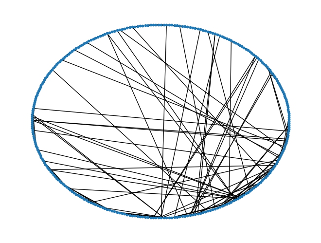

```python
possible_to_fly_graph(China, 100)
```

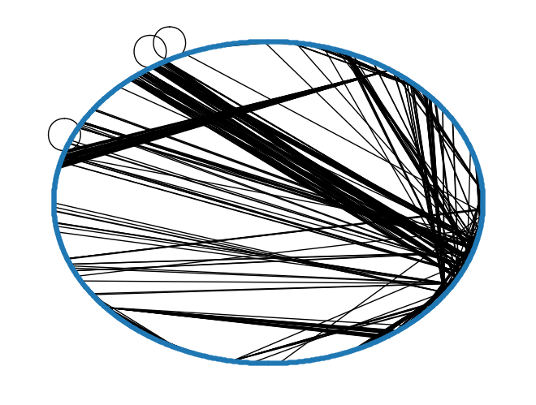

```python
possible_to_fly_graph(Canada, 100)
```

Вполне очевидно, что в Канаде и больше Аэропортов и выше их доступность

Посмотрим как расположены эти аэропорты в этих странах

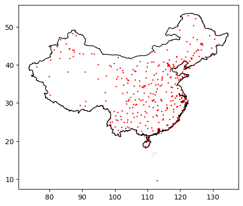

```python
airports_on_the_map("China")
```

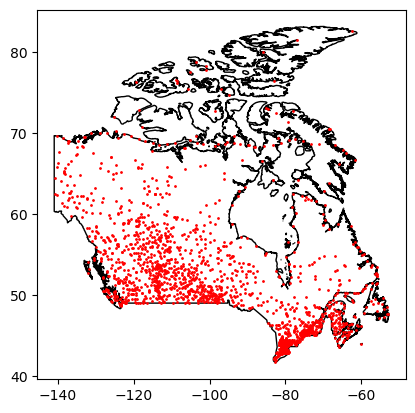

```python
airports_on_the_map("Canada")
```

Как видно, аэропорты сконцентрированы по большей части в тех местах, где проживает наибольшая часть населения как в Китае, так и в Канаде

Теперь посмотрим, какие виды аэропортов доминируют в этих двух странах

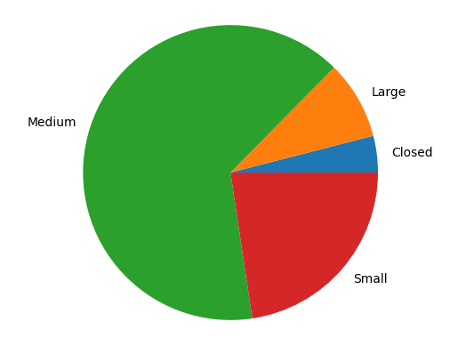

```python
airports_of_different_kinds(China)
```

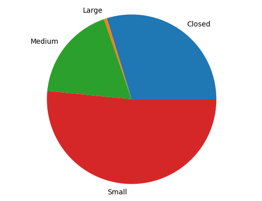

```python
airports_of_different_kinds(Canada)
```

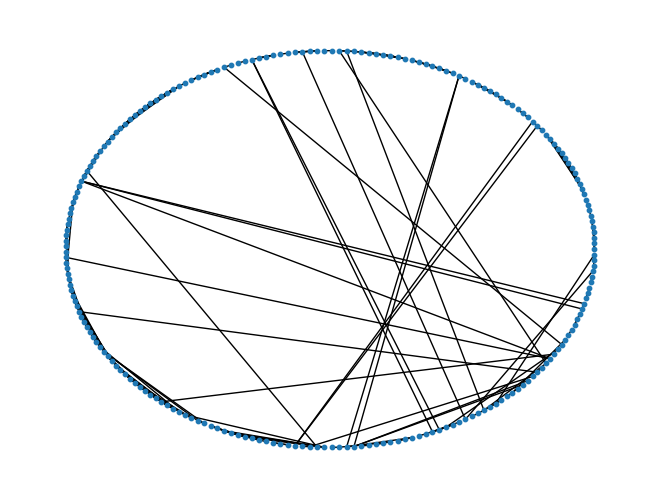

```python
possible_to_fly_medium_large_graph(China, 100)
```

Рассмотрим карты, на которых расположены большие и средние аэропорты

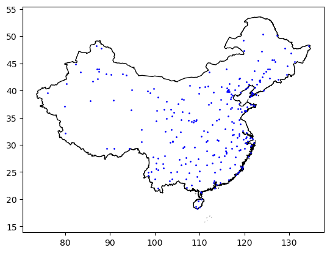

```python
airports_on_the_map_medium_large("China")
```

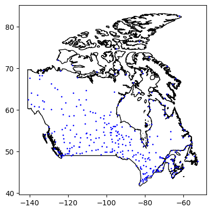

```python
airports_on_the_map_medium_large("Canada")
```

В данном случае трудно оченить визуально, в какой стране больше аэропортов, однако можно заметить, что большие и средние аэропорты в этих странах располагаются более равномерно, чем малые и закрытые

# Заключение

В своем проекте я создал небольшой инструментарий для анализа аэропортов различных стран и воспользовался им, чтобы проанализировать аэропорты Китая и Канады